# Homework-02

Julie Jung

October 2, 2017

Every Saturday, at the same time, a primatologist goes and sits in the forest in the morning and listens for titi monkey calls, counting the number of calls they hear in a 2 hour window from 5am to 7am. Based on previous knowledge, she believes that the mean number calls she will hear in that time is exactly 15. Let X represent the appropriate Poisson random variable of the number of calls heard in each monitoring session.

What is the probability that she will hear more than 8 calls during any given session?

```r
x <- 8
l <- 15

1-ppois(x,l) #1 - the probability of observing up to and including a specific number of events in the given interval (8)
```

```
## [1] 0.9625535
```

What is the probability that she will hear no calls in a session?

```r
x <- 0
l <- 15

dpois(x = x, lambda = l) # prob of hearing exactly x calls
```

```
## [1] 3.059023e-07
```

What is the probability that she will hear exactly 3 calls in a session?

```r
x <- 3
l <- 15

dpois(x = x, lambda = l)
```

```
## [1] 0.0001720701
```

Plot the relevant Poisson mass function over the values in range 0 ≤ x ≤ 30.

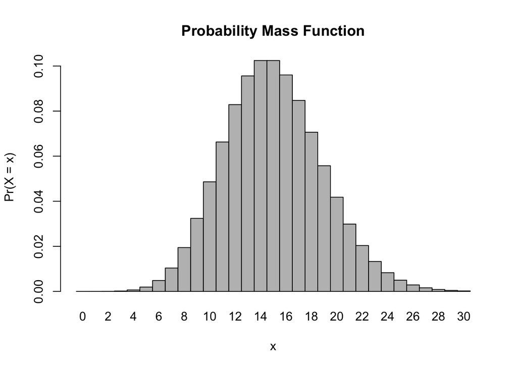

```r
x <- 0:30
l <- 15

barplot(dpois(x = x, lambda = l), names.arg = x, space = 0, xlab = "x", ylab = "Pr(X = x)", main = "Probability Mass Function")
```

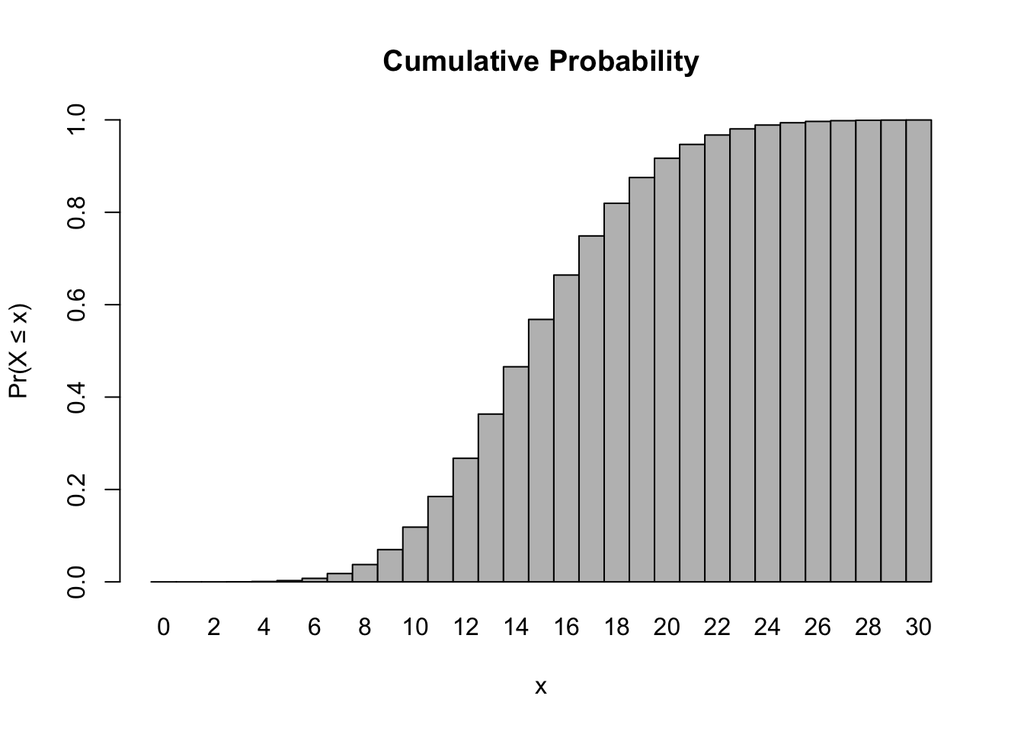

```r
barplot(ppois(q = x, lambda = l), ylim = 0:1, space = 0, names.arg = x, xlab = "x", ylab = "Pr(X ≤ x)", main = "Cumulative Probability")
```

Simulate 104 results from this distribution (i.e., 2 years of Saturday monitoring sessions).

```r
t <- 104
l <- 15
results <- rpois(t,l)
```

Plot the simulated results using hist() and use xlim() to set the horizontal limits to be from 0 to 30. How does your histogram compare to the shape of the probability mass function you plotted above?

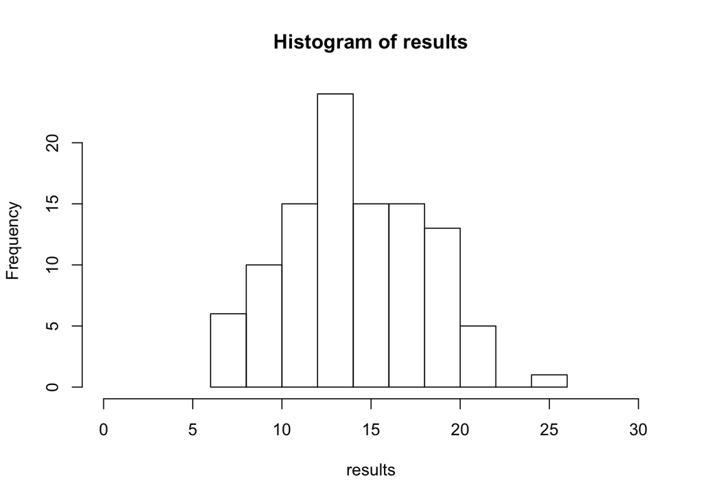

```r
library(ggplot2)
hist(results, xlim=c(0,30))
```

Probability Mass Functions (PMFs) are associated with discrete random variables. These functions describe the probability that a random variable takes a particular discrete value (or falling within a given range of outcome values).

To be a valid PMF, a function f(x)f(x) must satisfy the following:

1. There are k distinct outcomes x1,x2,…..,xk
2. 0 ≤ Pr (X=xi) ≤ 1 for all xi
3. ∑ Pr (X=xi) for all x from x1 to xk = 1

The simulated results plotted on a histogram are (simulated) observed count data (which occurred based on probabilities) rather than probabilities of occurence outright. The frequency indicates how many times (with what frequency) the observer heard x number (results, on x-axis) of titi monkey calls within 2 years of Saturday monitoring sessions. Wheras the PMF shows us the probability of observing x number of titi monkey calls within a period of 1 session.